# PRS Simulation: 2

Jack Pattee

9/25/2023

This RMarkdown executes simulations as described in ‘Hendricks Report 2’ (Sept 11, 2023). The structure of the simulation is described in that document; the inputs to the simulation are described here, the simulations themselves conducted, and the accuracy of the simulations is assessed.

The following describes the values the simulation parameter takes. Only one parameter varies at a time. Non-varying parameters always take the **bolded** value.

n: 1000, **2000**, 4000

t: 5, 10, **20**, 30, 50

Relative proportion of phenotypic variance controlled by $\sf{X_{\beta}}$, $\sf{Z_{\delta}}$, and $\sf{\epsilon}$, in ordered triplets.

.1, .1, .8

.2, .1, .7

**.3, .1, .6**

.4, .1, .5

.5, .1, .4

.6, .1, .3

.7, .1, .2

.1, .05, .85

.2, .05, .75

.3, .05, .65

.4, .05, .55

.5, .05, .45

.6, .05, .35

.7, .05, .25

Distribution of Z: Both Case 1 and Case 2 will be conducted for all other simulation settings (except for $p$, as below, which will only be done for Case 2).

When Z is distributed as Case 2, the proportion of structural covariate Z draws that is distributed at point mass zero: .2, **.5**, .8.

In the case of Z distributed according to case 2, the environmental error is bimodal. In this case, the ‘effectiveness’ will be assessed according to accuracy of k-means clustering. Specifically, k-means clusters will be estimated with two cluster centers, and cluster quality will be assessed using the adjusted Rand index. In the case of Z distributed according to case 1, the structural error is unimodal. In both case 1 and case 2, the effectiveness of the method will be assessed as the proportion of variation in environmental error explained by each of the first five principal components in single linear regression. Each simulation is run for 200 replications.

Table 1: Simulation Settings

| Setting | n | t | vxb | vzd | ve | Zset | Zp |
| --- | --- | --- | --- | --- | --- | --- | --- |
| 1 | 2000 | 20 | 0.3 | 0.10 | 0.60 | 3 | 0.5 |
| 2 | 1000 | 20 | 0.3 | 0.10 | 0.60 | 3 | 0.5 |
| 3 | 4000 | 20 | 0.3 | 0.10 | 0.60 | 3 | 0.5 |
| 4 | 2000 | 5 | 0.3 | 0.10 | 0.60 | 3 | 0.5 |
| 5 | 2000 | 10 | 0.3 | 0.10 | 0.60 | 3 | 0.5 |
| 6 | 2000 | 30 | 0.3 | 0.10 | 0.60 | 3 | 0.5 |
| 7 | 2000 | 50 | 0.3 | 0.10 | 0.60 | 3 | 0.5 |
| 8 | 2000 | 20 | 0.1 | 0.10 | 0.80 | 3 | 0.5 |
| 9 | 2000 | 20 | 0.2 | 0.10 | 0.70 | 3 | 0.5 |
| 10 | 2000 | 20 | 0.4 | 0.10 | 0.50 | 3 | 0.5 |
| 11 | 2000 | 20 | 0.5 | 0.10 | 0.40 | 3 | 0.5 |
| 12 | 2000 | 20 | 0.6 | 0.10 | 0.30 | 3 | 0.5 |
| 13 | 2000 | 20 | 0.7 | 0.10 | 0.20 | 3 | 0.5 |
| 14 | 2000 | 20 | 0.1 | 0.05 | 0.85 | 3 | 0.5 |
| 15 | 2000 | 20 | 0.2 | 0.05 | 0.75 | 3 | 0.5 |
| 16 | 2000 | 20 | 0.3 | 0.05 | 0.65 | 3 | 0.5 |
| 17 | 2000 | 20 | 0.4 | 0.05 | 0.55 | 3 | 0.5 |
| 18 | 2000 | 20 | 0.5 | 0.05 | 0.45 | 3 | 0.5 |
| 19 | 2000 | 20 | 0.6 | 0.05 | 0.35 | 3 | 0.5 |
| 20 | 2000 | 20 | 0.7 | 0.05 | 0.25 | 3 | 0.5 |
| 21 | 2000 | 20 | 0.3 | 0.10 | 0.60 | 1 | 0.5 |
| 22 | 1000 | 20 | 0.3 | 0.10 | 0.60 | 1 | 0.5 |
| 23 | 4000 | 20 | 0.3 | 0.10 | 0.60 | 1 | 0.5 |
| 24 | 2000 | 5 | 0.3 | 0.10 | 0.60 | 1 | 0.5 |
| 25 | 2000 | 10 | 0.3 | 0.10 | 0.60 | 1 | 0.5 |
| 26 | 2000 | 30 | 0.3 | 0.10 | 0.60 | 1 | 0.5 |
| 27 | 2000 | 50 | 0.3 | 0.10 | 0.60 | 1 | 0.5 |
| 28 | 2000 | 20 | 0.1 | 0.10 | 0.80 | 1 | 0.5 |
| 29 | 2000 | 20 | 0.2 | 0.10 | 0.70 | 1 | 0.5 |
| 30 | 2000 | 20 | 0.4 | 0.10 | 0.50 | 1 | 0.5 |
| 31 | 2000 | 20 | 0.5 | 0.10 | 0.40 | 1 | 0.5 |
| 32 | 2000 | 20 | 0.6 | 0.10 | 0.30 | 1 | 0.5 |
| 33 | 2000 | 20 | 0.7 | 0.10 | 0.20 | 1 | 0.5 |
| 34 | 2000 | 20 | 0.1 | 0.05 | 0.85 | 1 | 0.5 |
| 35 | 2000 | 20 | 0.2 | 0.05 | 0.75 | 1 | 0.5 |
| 36 | 2000 | 20 | 0.3 | 0.05 | 0.65 | 1 | 0.5 |
| 37 | 2000 | 20 | 0.4 | 0.05 | 0.55 | 1 | 0.5 |
| 38 | 2000 | 20 | 0.5 | 0.05 | 0.45 | 1 | 0.5 |
| 39 | 2000 | 20 | 0.6 | 0.05 | 0.35 | 1 | 0.5 |
| 40 | 2000 | 20 | 0.7 | 0.05 | 0.25 | 1 | 0.5 |
| 41 | 2000 | 20 | 0.3 | 0.10 | 0.60 | 3 | 0.2 |
| 42 | 2000 | 20 | 0.3 | 0.10 | 0.60 | 3 | 0.8 |

Visualizations of clustering accuracy against VXB, with other parameters held constant (except for VE, which varies with VXB). Boxplots of clustering accuracy by simulation setting. Simulation setting (according to rows of Table 1) is annotated to each boxplot.

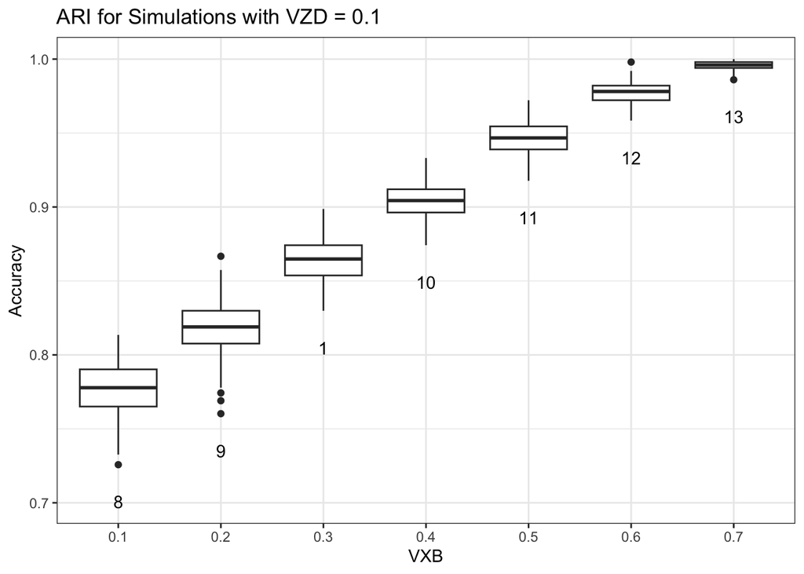

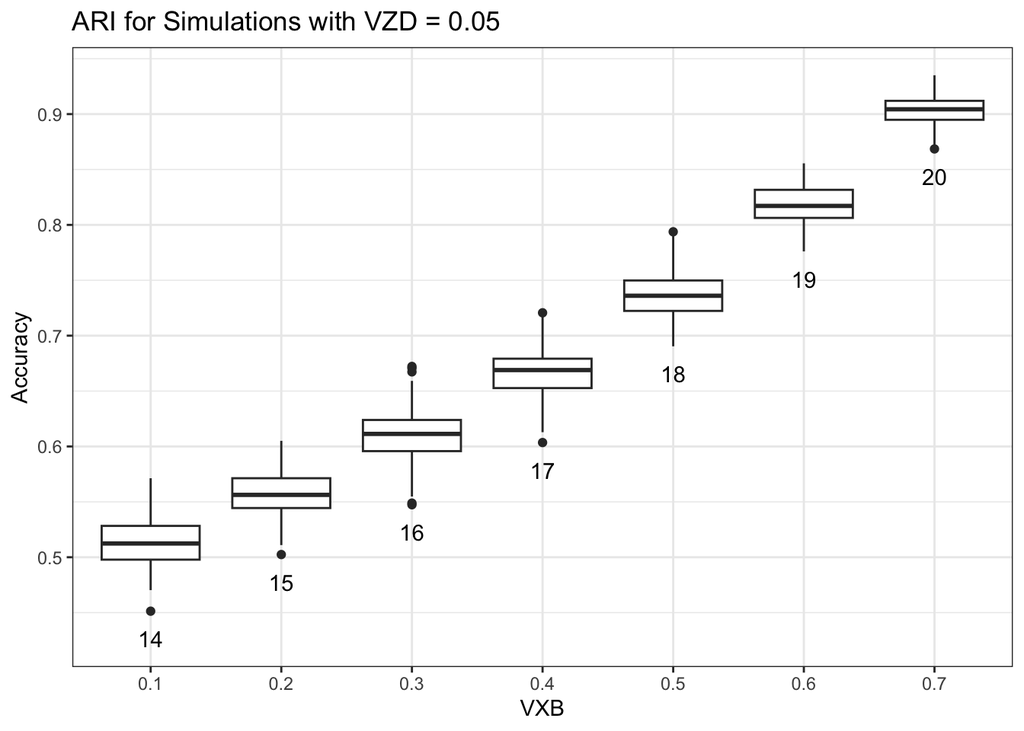

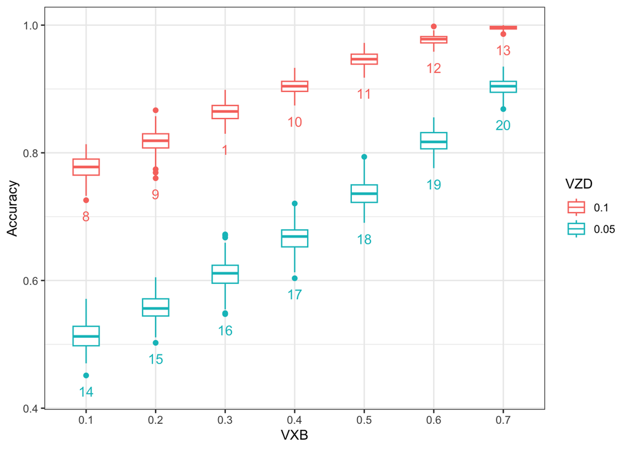

Visualize clustering accuracy against the number of traits.

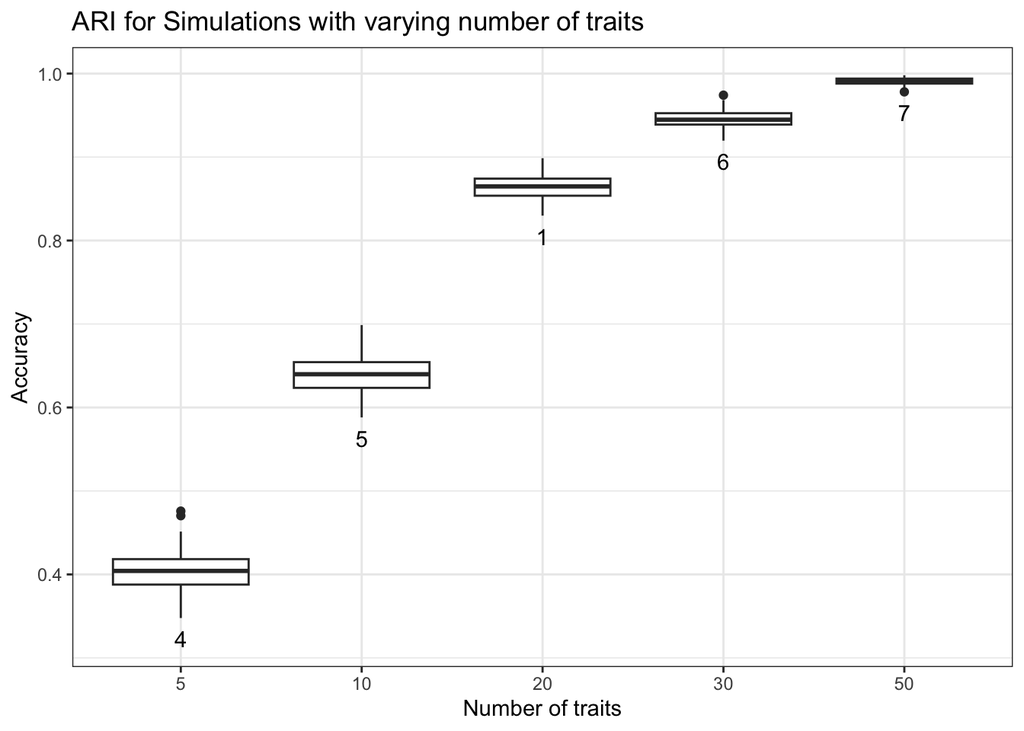

Visualize clustering accuracy against the number of subjects.

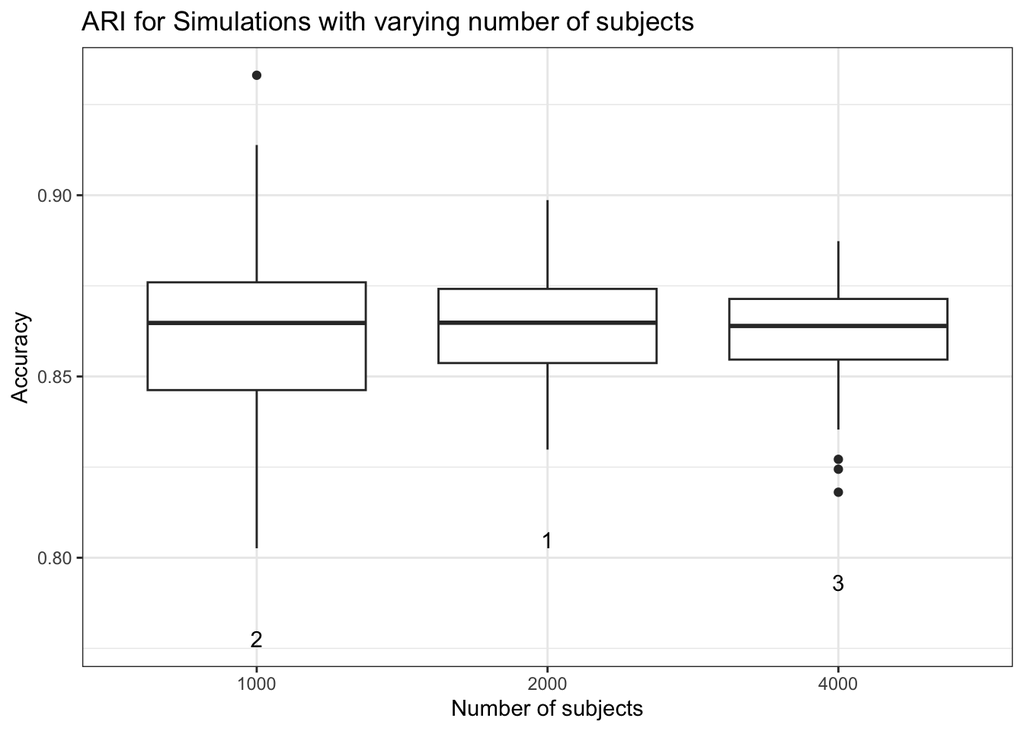

Visualize clustering accuracy against p, the proportion of subjects with no structural contribution to error.

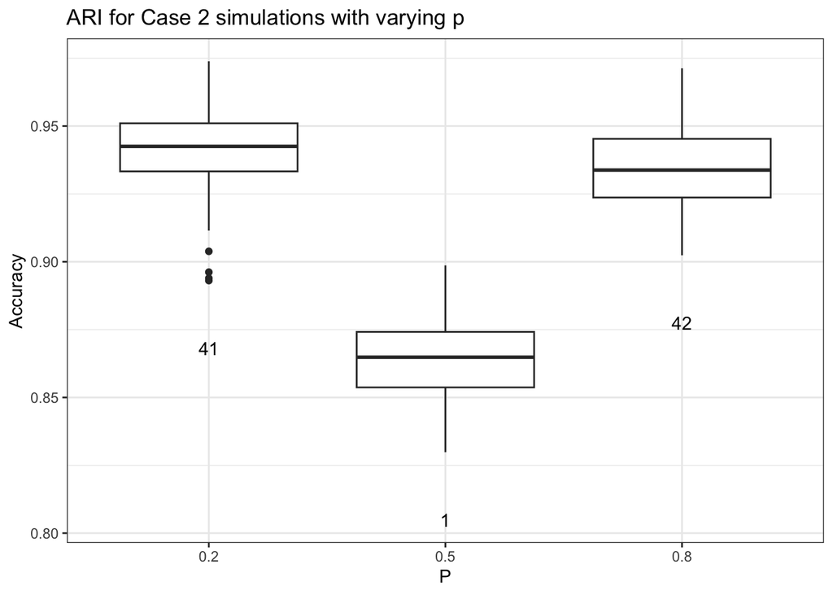

Visualization of the proportion of variance explained by the first PC against VXB, with other parameters held constant (except for VE, which varies with VXB).

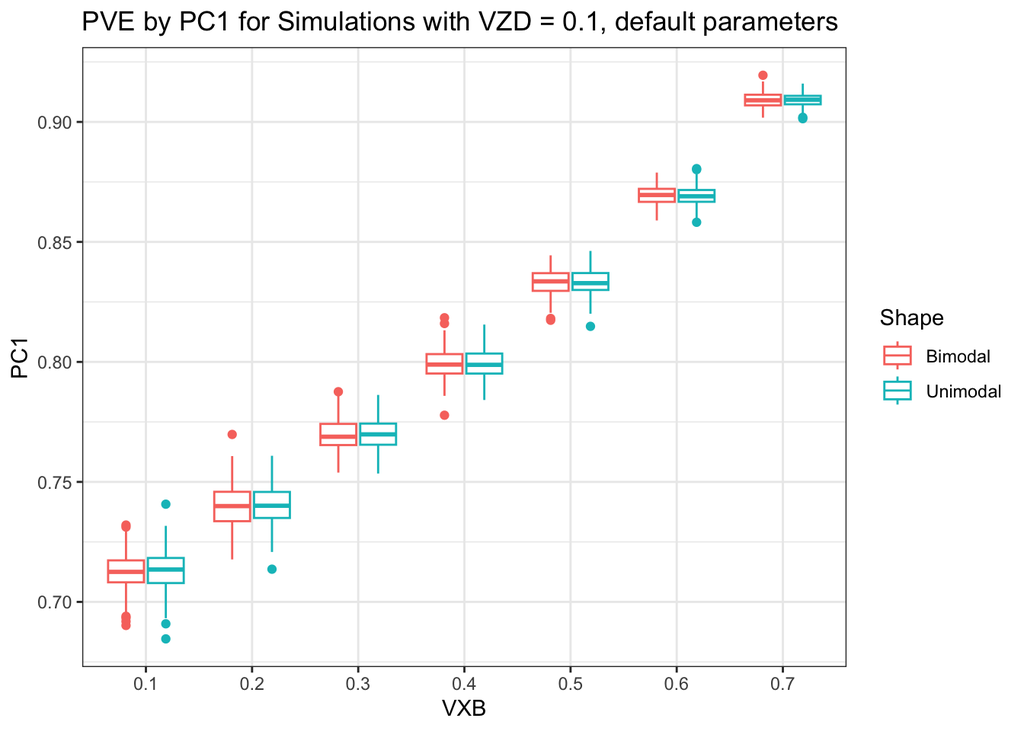

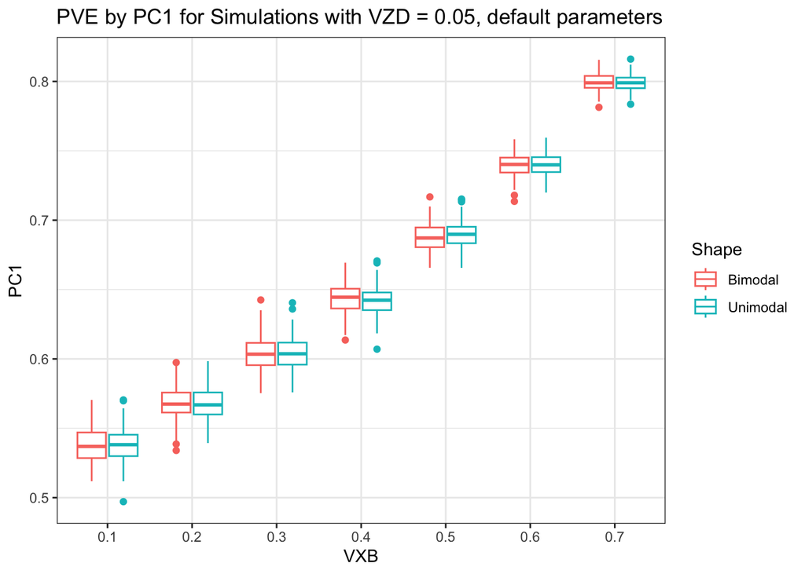

Visualize PVE by the first PC against the number of traits.

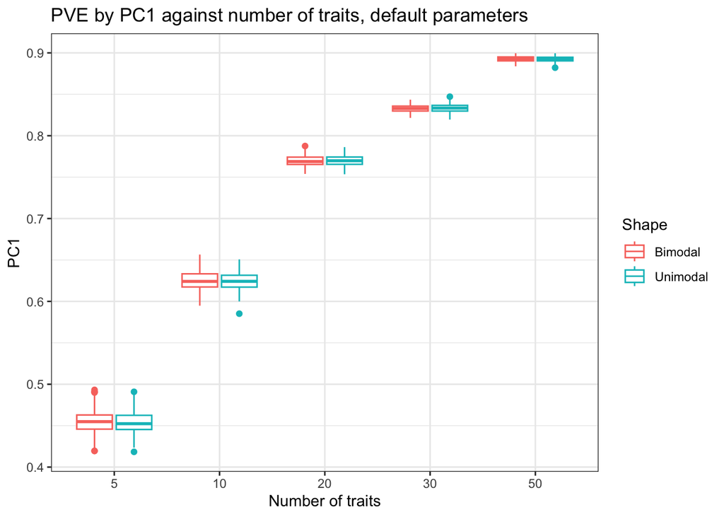

Visualize PVE by the first PC against the number of subjects.

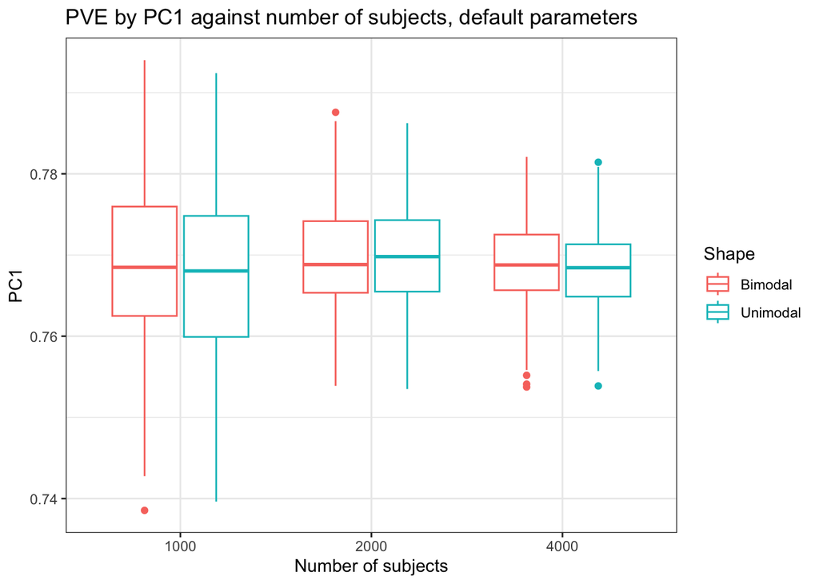

Example plots of $\sf{X_{\beta}}$, $\sf{Z_{\delta}}$, and $\sf{\epsilon}$ for a single phenotype in some simulation settings.

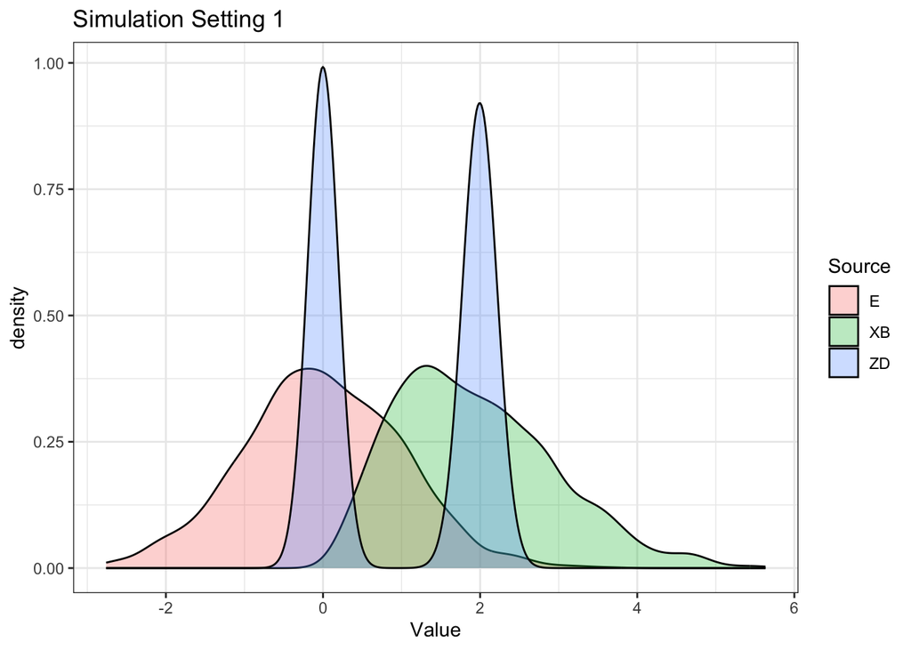

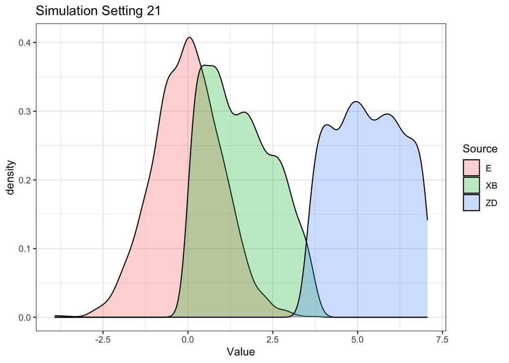